# Assignment - 5 (ANN)

## Neural network using Keras

#### Author: [Jimut Bahan Pal](https://jimut123.github.io/)

#### Question

Import the Iris dataset and divide the data into training and test datasets.

a) Train a 2-layered neural network (1 hidden layer) model on the data. Employ Batch normalization and initialize the weights using the Xaviers method with normal distribution. Make predictions on the test data and compute the accuracy.

b) Vary the number of neurons in the hidden layer and show the impact on accuracy.

c) Take (one of) the case which has best accuracy and employ dropout with different values of dropout rate (say from 0.1 to 0.7). Plot the variation of accuracy versus dropout rate.

d) Now increase the number of hidden layers (with same no. of neurons) and show the variation of accuracy with respect to the number of hidden layers. You can select the number of neurons as determined best in part b)

e) Using the setting as determined best in part b), train the model with a few different optimization algorithms (with default settings) and print the accuracy from each case. You may try adam, adagrad, adadelta.

Hint (python): from keras.models import Sequential from keras.layers import Dense

model = Sequential() model.add(Dense(5, input_dim=2, activation='relu')) model.add(Dense(4, activation='softmax')) model.compile(loss='categorical_crossentropy', optimizer='adam', metrics=['accuracy'])

### Loading the necessary libraries

```python
import pandas as pd
import numpy as np
from sklearn import datasets
import seaborn as sns
import matplotlib.pyplot as plt
from matplotlib.colors import ListedColormap
from sklearn.datasets import load_iris
from keras.models import Sequential
from keras.layers import Dense,Dropout
from keras.optimizers import SGD,Adam
from keras import optimizers
from sklearn.model_selection import train_test_split
from sklearn.preprocessing import LabelEncoder
from tensorflow.python.keras.utils import np_utils
from keras.layers.normalization import BatchNormalization
from keras.utils.vis_utils import plot_model  #plotting the model structure
```

## Loading the iris data

```python
iris = datasets.load_iris()
X_data = iris.data[:,0:4].astype(float)  # 4-features
Y_data = iris.target # labels (3 classes)
```

```python
encoder = LabelEncoder()
```

```python
encoder.fit(Y_data)
```

```
LabelEncoder()
```

```python
encoded_Y = encoder.transform(Y_data)
```

```python
dummy_y = np_utils.to_categorical(encoded_Y)
```

## Dividing the data into training and test dataset

```python
#dummy_y
# set aside 20% of train and test data for evaluation
X_train, X_test, y_train, y_test = train_test_split(X_data, dummy_y,
    test_size=0.2, shuffle = True, random_state = 123)
print("X_train shape: {}".format(X_train.shape))
print("X_test shape: {}".format(X_test.shape))
print("y_train shape: {}".format(y_train.shape))
print("y_test shape: {}".format(y_test.shape))
```

```
X_train shape: (120, 4)
X_test shape: (30, 4)
y_train shape: (120, 3)
y_test shape: (30, 3)
```

```python
print(X_train[:10])
```

```
[[7.4 2.8 6.1 1.9]
 [6.  2.2 5.  1.5]
 [4.7 3.2 1.6 0.2]
 [5.1 3.5 1.4 0.2]
 [6.  2.2 4.  1. ]
 [5.  2.3 3.3 1. ]
 [7.9 3.8 6.4 2. ]
 [5.4 3.9 1.7 0.4]
 [5.4 3.9 1.3 0.4]
 [5.8 2.7 3.9 1.2]]
```

```python
# get reproducible results:: 99.17%
# Seed value
# Apparently you may use different seed values at each stage
seed_value= 0
import tensorflow as tf
# 1. Set the `PYTHONHASHSEED` environment variable at a fixed value
import os
os.environ['PYTHONHASHSEED']=str(seed_value)

# 2. Set the `python` built-in pseudo-random generator at a fixed value
import random
random.seed(seed_value)

# 3. Set the `numpy` pseudo-random generator at a fixed value
import numpy as np
np.random.seed(seed_value)

# 4. Set the `tensorflow` pseudo-random generator at a fixed value
import tensorflow as tf
tf.random.set_seed(seed_value)
# for later versions:
# tf.compat.v1.set_random_seed(seed_value)


# for later versions:
# session_conf = tf.compat.v1.ConfigProto(intra_op_parallelism_threads=1, inter_op_parallelism_threads=1)
# sess = tf.compat.v1.Session(graph=tf.compat.v1.get_default_graph(), config=session_conf)
# tf.compat.v1.keras.backend.set_session(sess)
```

## a)

### Train a 2-layered neural network (1 hidden layer) model on the data.

### Employ Batch normalization and initialize the weights using the Xaviers method with normal distribution.

### Make predictions on the test data and compute the accuracy.

```python
#Defining the model

# Seq approach
model = Sequential()
# input dimension is 4 since there are 4 features (input layer)
model.add(Dense(4, input_dim=4, activation='softmax'))
# 1st hidden layer
# initialising the weights using Xavier's Method
model.add(Dense(10, activation='softmax',kernel_initializer = 'glorot_normal'))
model.add(BatchNormalization())
# 2nd layer is output layer
model.add(Dense(3, activation='softmax'))
# output layer
model.compile(loss='categorical_crossentropy', optimizer='adam', metrics=['accuracy'])
model.summary()
```

```
Model: "sequential_1"
_________________________________________________________________
Layer (type)                 Output Shape              Param #
=================================================================
dense_1 (Dense)              (None, 4)                 20
_________________________________________________________________
dense_2 (Dense)              (None, 10)                50
_________________________________________________________________
batch_normalization_1 (Batch (None, 10)                40
_________________________________________________________________
dense_3 (Dense)              (None, 3)                 33
=================================================================
Total params: 143
Trainable params: 123
Non-trainable params: 20
_________________________________________________________________
```

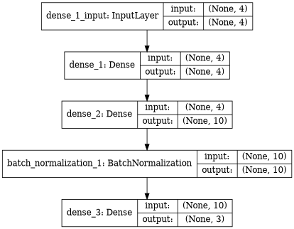

```python
plot_model(model, to_file='model_plot.png', show_shapes=True, show_layer_names=True,dpi=60)
```

```python
#fitting the model and predicting
hist = model.fit(X_train,y_train,epochs=100)
```

```python
print(hist.history.keys())
```

```
dict_keys(['loss', 'accuracy'])
```

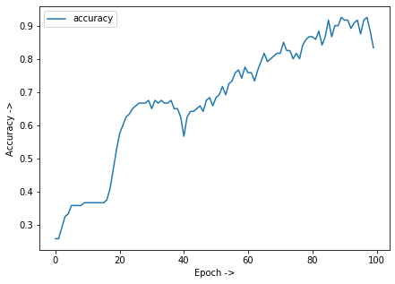

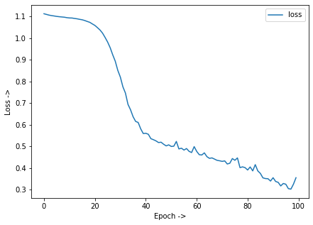

```python
plt.figure(figsize=(7,5))
legend_acc = []
for item in hist.history.keys():
    if item.split('_')[-1:] == ['accuracy']:
        #print("Accuracy = ",item)
        legend_acc.append(item)
        plt.plot(hist.history[item])
plt.ylabel('Accuracy ->')
plt.xlabel('Epoch ->')
plt.legend(legend_acc, loc='upper left')
plt.show()

plt.figure(figsize=(7,5))
legend_acc = []
for item in hist.history.keys():
    if item.split('_')[-1:] == ['loss']:
        #print("Accuracy = ",item)
        legend_acc.append(item)
        plt.plot(hist.history[item])
plt.ylabel('Loss ->')
plt.xlabel('Epoch ->')
plt.legend(legend_acc, loc='upper right')
plt.show()
```

```python
y_pred = model.predict(X_test)

y_test_class = np.argmax(y_test,axis=1)
y_pred_class = np.argmax(y_pred,axis=1)
```

```python
print(y_pred)
print(y_test_class)
print(y_pred_class)
```

```
[[0.09890788 0.64731497 0.2537772 ]
 [0.04914845 0.58929026 0.36156127]
 [0.03867501 0.5637737  0.3975513 ]
 [0.11557894 0.6496424  0.23477863]
 [0.6503627  0.31497464 0.03466271]
 [0.06067329 0.61122406 0.32810265]
 [0.19335772 0.6398732  0.16676906]
 [0.62054306 0.34025338 0.03920352]
 [0.6223265  0.33880046 0.03887304]
 [0.1037725  0.6507972  0.24543034]
 [0.06039342 0.60723007 0.33237645]
 [0.6732332  0.29544082 0.03132604]
 [0.10907686 0.6496358  0.24128729]
 [0.04907482 0.59123677 0.35968846]
 [0.04779161 0.5852524  0.36695597]
 [0.03474224 0.5498999  0.41535786]
 [0.7077717  0.26564255 0.02658576]
 [0.656733   0.3095983  0.03366867]
 [0.09372076 0.64337194 0.26290736]
 [0.651472   0.31406128 0.03446671]
 [0.6790975  0.2904024  0.03050014]
 [0.07452545 0.630643   0.29483148]
 [0.55858576 0.3916591  0.04975515]
 [0.05973415 0.60986656 0.33039925]
 [0.62442726 0.33689493 0.03867782]
 [0.66258955 0.3045409  0.03286951]
 [0.67073905 0.29757932 0.03168161]
 [0.04395211 0.57989144 0.37615648]
 [0.03018782 0.5287199  0.44109222]
 [0.65192384 0.31364352 0.03443266]]
[1 2 2 1 0 2 1 0 0 1 2 0 1 2 2 2 0 0 1 0 0 2 0 2 0 0 0 2 2 0]
[1 1 1 1 0 1 1 0 0 1 1 0 1 1 1 1 0 0 1 0 0 1 0 1 0 0 0 1 1 0]
```

## b)

### Vary the number of neurons in the hidden layer and show the impact on accuracy.

#### Lets brute force crazily, starting from Number of Neurons in hidden layer = 4

```
Hidden Neurons =>  4
Accuracy =>  0.94166666
```

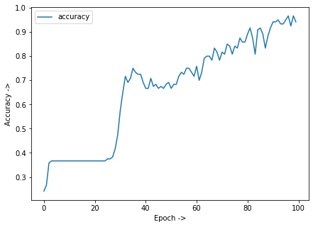

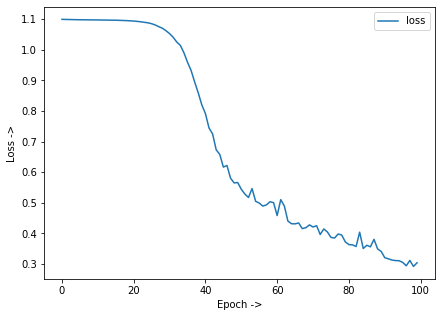

```
Hidden Neurons =>  5
Accuracy =>  0.98333335
```

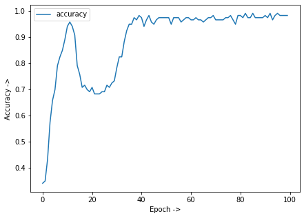

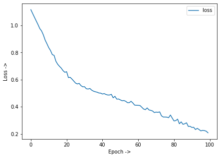

```
Hidden Neurons =>  6
Accuracy =>  0.9583333
```

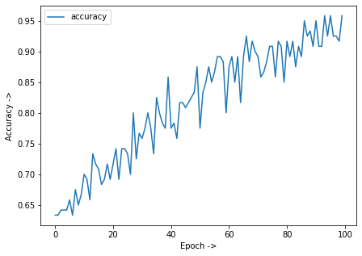

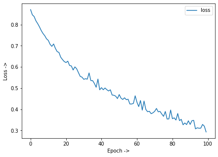

```
Hidden Neurons =>  7
Accuracy =>  0.90833336
```

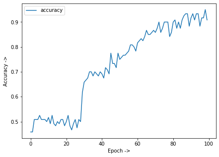

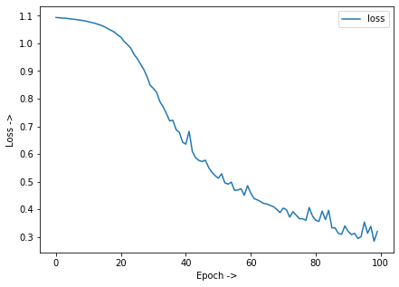

```
Hidden Neurons =>  8
Accuracy =>  0.94166666
```

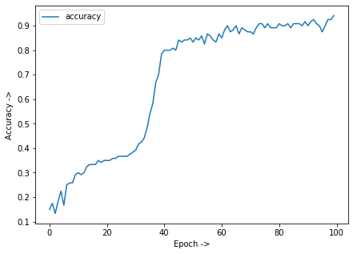

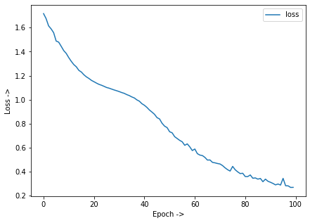

```
Hidden Neurons =>  9
Accuracy =>  0.9583333
```

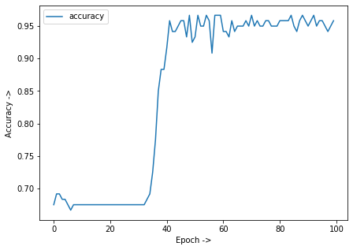

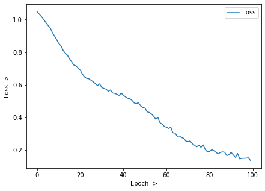

```
Hidden Neurons =>  10
Accuracy =>  0.925
```

[80 more figures not shown]

```python
deep_neurons = 50
accuracy_neuron_list = []

for item in range(4,deep_neurons):
    model = Sequential()
    # input dimension is 4 since there are 4 features (input layer)
    model.add(Dense(4, input_dim=4, activation='softmax'))
    # 1st hidden layer
    # initialising the weights using Xavier's Method
    model.add(Dense(item, activation='softmax',kernel_initializer = 'glorot_normal'))
    model.add(BatchNormalization())
    # 2nd layer is output layer
    model.add(Dense(3, activation='softmax'))
    # output layer
    model.compile(loss='categorical_crossentropy', optimizer='adam', metrics=['accuracy'])
    hist = model.fit(X_train,y_train,epochs=100,verbose=0)
    #model.summary()

    print("Hidden Neurons => ",item)
    print("Accuracy => ",hist.history.get('accuracy')[-1])
    accuracy_neuron_list.append([item,hist.history.get('accuracy')[-1]])
    plt.figure(figsize=(7,5))
    legend_acc = []
    for item in hist.history.keys():
        if item.split('_')[-1:] == ['accuracy']:
            #print("Accuracy = ",item)
            legend_acc.append(item)
            plt.plot(hist.history[item])
    plt.ylabel('Accuracy ->')
    plt.xlabel('Epoch ->')
    plt.legend(legend_acc, loc='upper left')
    plt.show()

    plt.figure(figsize=(7,5))
    legend_acc = []
    for item in hist.history.keys():
        if item.split('_')[-1:] == ['loss']:
            #print("Accuracy = ",item)
            legend_acc.append(item)
            plt.plot(hist.history[item])
    plt.ylabel('Loss ->')
    plt.xlabel('Epoch ->')
    plt.legend(legend_acc, loc='upper right')
    plt.show()
```

```python
print(accuracy_neuron_list)
```

[output not shown]

```python
#accuracy_neuron_list
print("No. of Hidden Neurons selected => ", 18)
```

```
No. of Hidden Neurons selected =>  18
```

```python
print("Max accuracy got =>",max(second))
```

```
Max accuracy got => 0.9916667
```

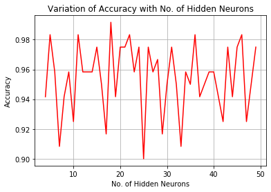

```python
first = [i[0] for i in accuracy_neuron_list]
second = [i[1] for i in accuracy_neuron_list]
fig, ax = plt.subplots()
ax.plot(first, second,color='red')

ax.set(xlabel='No. of Hidden Neurons', ylabel='Accuracy',
       title='Variation of Accuracy with No. of Hidden Neurons')
ax.grid()
plt.show()
```

#### So we have brute forced and got number of neuron = 18

## c)

### Take (one of) the case which has best accuracy and employ dropout with different values of dropout rate (say from 0.1 to 0.7). Plot the variation of accuracy versus dropout rate.

```
Dropout =>  0.1
Accuracy =>  0.69166666
```

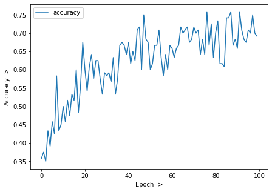

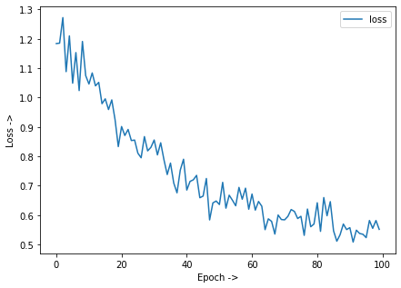

```
Dropout =>  0.2
Accuracy =>  0.7083333
```

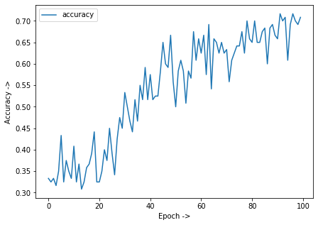

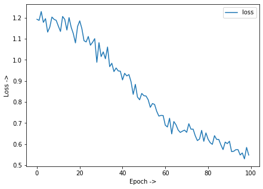

```
Dropout =>  0.3
Accuracy =>  0.65
```

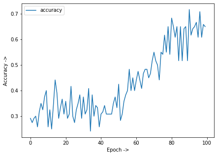

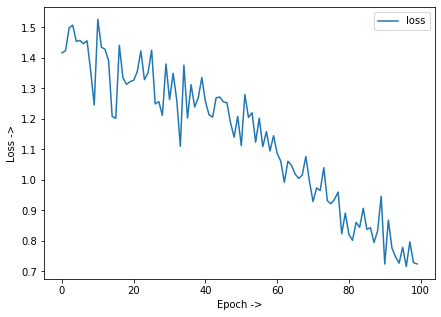

```
Dropout =>  0.4
Accuracy =>  0.69166666
```

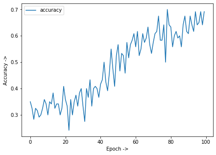

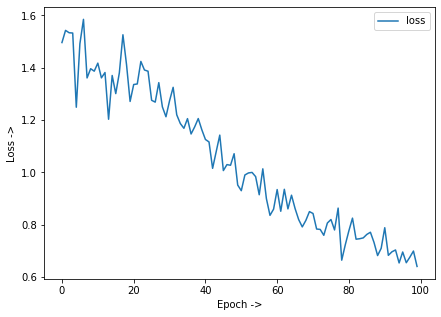

```
Dropout =>  0.5
Accuracy =>  0.7
```

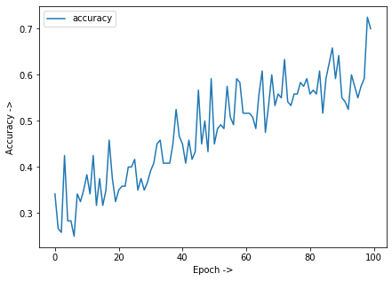

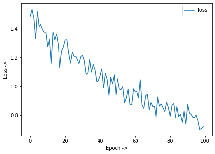

```
Dropout =>  0.6
Accuracy =>  0.55833334
```

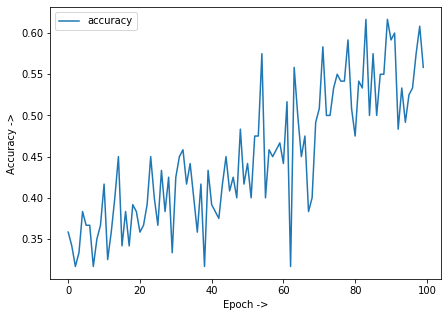

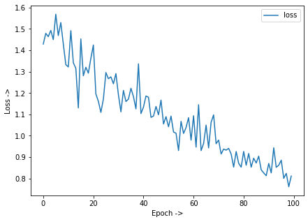

```
Dropout =>  0.7
Accuracy =>  0.425
```

[2 more figures not shown]

```python
dropout_acc_list = []
for dropout_ in range(1,8):
    dropout = dropout_/10
    #print(dropout)
    #Defining the model

    # Seq approach
    model = Sequential()
    # input dimension is 4 since there are 4 features (input layer)
    model.add(Dense(4, input_dim=4, activation='softmax'))
    # 1st hidden layer
    # initialising the weights using Xavier's Method
    model.add(Dense(18, activation='softmax',kernel_initializer = 'glorot_normal'))
    model.add(Dropout(dropout))
    model.add(BatchNormalization())
    # 2nd layer is output layer
    model.add(Dense(3, activation='softmax'))
    # output layer
    model.compile(loss='categorical_crossentropy', optimizer='adam', metrics=['accuracy'])
    #model.summary()
    hist = model.fit(X_train,y_train,epochs=100,verbose=0)
    print("Dropout => ",dropout)
    print("Accuracy => ",hist.history.get('accuracy')[-1])
    dropout_acc_list.append([dropout,hist.history.get('accuracy')[-1]])
    plt.figure(figsize=(7,5))
    legend_acc = []
    for item in hist.history.keys():
        if item.split('_')[-1:] == ['accuracy']:
            #print("Accuracy = ",item)
            legend_acc.append(item)
            plt.plot(hist.history[item])
    plt.ylabel('Accuracy ->')
    plt.xlabel('Epoch ->')
    plt.legend(legend_acc, loc='upper left')
    plt.show()

    plt.figure(figsize=(7,5))
    legend_acc = []
    for item in hist.history.keys():
        if item.split('_')[-1:] == ['loss']:
            #print("Accuracy = ",item)
            legend_acc.append(item)
            plt.plot(hist.history[item])
    plt.ylabel('Loss ->')
    plt.xlabel('Epoch ->')
    plt.legend(legend_acc, loc='upper right')
    plt.show()
```

```python
dropout_acc_list
```

```
[[0.1, 0.69166666],
 [0.2, 0.7083333],
 [0.3, 0.65],
 [0.4, 0.69166666],
 [0.5, 0.7],
 [0.6, 0.55833334],
 [0.7, 0.425]]
```

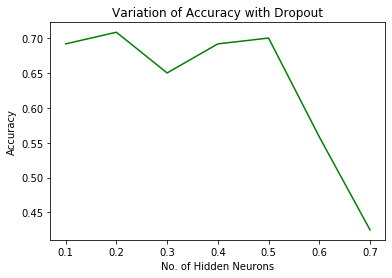

```python
first_d = [i[0] for i in dropout_acc_list]
second_d = [i[1] for i in dropout_acc_list]
fig, ax = plt.subplots()
ax.plot(first_d, second_d,color='green')

ax.set(xlabel='No. of Hidden Neurons', ylabel='Accuracy',
       title='Variation of Accuracy with Dropout')
#ax.grid()
plt.show()
```